# Unimed Vitória teste de proficiência em data science

Abrantes Araújo Silva Filho

2017-10-28

## Introdução

Este documento apresenta minha análise de um estudo de caso preparado pela Unimed Vitória, como teste de proficiência em Data Science.

Como o limite de tempo para a realização deste estudo de caso foi de 6 horas, optei por realizar e apresentar todas as etapas da análise do começo ao fim sem, no entanto, testar diversos modelos e/ou variações nos parâmetros e ajustes possíveis nos diversos algoritmos.

Meu objetivo neste estudo de caso foi apresentar todas as etapas do **processo de análise**, sem um detalhamento extremo de cada fase (o que levaria dias de análise): por exemplo, técnicas de *emsemble* não foram utilizadas.

Os arquivos necessários para a reprodução deste estudo de caso estão em meu repositório no GitHub: github.com/abrantesasf/unimed.

## Problema proposto: *visão do negócio*

Uma corretora de valores que orienta seus clientes a investirem em opções no mercado financeiro, gostaria de agrupar esses clientes em grupos bem definidos de acordo com características em comum.

Com esse intuito a corretora forneceu um arquivo de planilha eletrônica em formato Microsoft Excel contento informações sobre diversas características desses clientes.

O trabalho deste estudo de caso consiste em analisar esses dados e encontrar esses grupos de clientes baseados.

## Problema proposto: *visão da análise*

Esse é um problema clássico já bem estudado na literature de *data mining* e *machine learning*, classificando-se na categoria de *unsupervised learning* na qual temos um conjunto de dados sem uma variável resposta (chamada de *label*) e queremos compreender a relação entre as diversas características dos objetos em estudo e identificar padrões.

Diversas técnicas de *unsupervised learning* existem, como por exemplo:

- Clustering
- Association Rule Mining
- Affinity Analysis
- Dimensionality Reduction

Para o problema proposto o mais indicado é utilizar algum algoritmo de *clustering*, já que o objetivo do *clustering* é particionar um conjunto de dados em grupos que sejam os mais similares possíveis (o ideal é que existe alta similaridade intra-grupo e alta dissimilaridade inter-grupos).

Como a análise de clustering é um processo altamente iterativo (envolvendo a modelagem, julgamento do modelo, ajustes do modelo e novo julgamento) até que o resultado seja considerado satisfatório, o limite de tempo imposto pelo estudo de caso limitará também a quantidade e a profundidade das análises realizadas.

## Ambiente de análise

O estudo de caso exigia a utilização do R, apesar de outros softwares também proporcionarem ferramentas de *clustering* (como Matlab, Python com scikit-learn, Weka e outros).

Meu ambiente de trabalho é um notebook Linux (Fedora 26, 64 bits, com 6 GB RAM), com a seguinte versão do R instalada:

```r
version
```

```
##                _
## platform       x86_64-redhat-linux-gnu
## arch           x86_64
## os             linux-gnu
## system         x86_64, linux-gnu
## status
## major          3
## minor          4.1
## year           2017
## month          06
## day            30
## svn rev        72865
## language       R
## version.string R version 3.4.1 (2017-06-30)
## nickname       Single Candle
```

Toda análise foi realizada com a IDE [RStudio](https://www.rstudio.com/) e todos os códigos foram escritos em [R Markdown](http://rmarkdown.rstudio.com/) para reprodutibilidade.

### Diretório de trabalho

Definição do diretório de trabalho:

```r
setwd("~/repositoriosGit/unimed/R_code")
```

### Carga de packages

Os seguintes packages foram carregados e utilizaos:

```r
library("ggplot2")
library("xlsx")
```

## Leitura e carga dos dados

Os dados foram fornecidos em um arquivo Micrisoft Excel com duas planilhas: “Dados” e “DEPARA”. Somente a planilha “Dados” nos interessa:

```r
# Lê os dados para o data frame df, já convertendo as strings como factors (nem sempre isso
# será a melhor opção, mas para uma análise inicial e rápida pode ser feito):
df <- read.xlsx("../data/DataSet.xlsx", sheetName = "Dados")
```

## Conhecendo o dataset, limpeza e organização

```r
# Verifica estrutura do df:
str(df)
```

```
## 'data.frame':    4972 obs. of  11 variables:
##  $ ID             : num  1 2 3 4 5 6 7 8 9 10 ...
##  $ GEO_REFERENCIA : num  780 35 54 35 883 78 131 97 351 51 ...
##  $ DATA_NASCIMENTO: POSIXct, format: "1992-08-15 00:00:00" "1990-02-24 00:00:00" ...
##  $ PROFISSAO      : Factor w/ 79 levels "ADMINISTRADOR",..: 5 66 5 11 68 9 10 25 77 19 ...
##  $ GENERO         : Factor w/ 2 levels "F","M": 2 1 2 2 2 2 2 2 2 2 ...
##  $ ESTADO_CIVIL   : Factor w/ 8 levels "CASADO(A) COM BRASILEIRO(A) NATO(A)",..: 6 6 6 1 1 6 6 6 6 1 ...
##  $ VALOR_01       : num  343 943 2000 857 8615 ...
##  $ VALOR_02       : num  343 0 0 286 0 ...
##  $ VALOR_03       : num  429 0 0 0 0 ...
##  $ VALOR_04       : num  28.6 0 2857.1 1428.6 47471.8 ...
##  $ PERFIL         : Factor w/ 4 levels "A","B","C","D": 1 1 1 1 1 2 1 1 1 1 ...
```

Temos um dataset com 4.972 observações e 11 variáveis, sendo a primeira a ID de cada cliente. As variáveis string já foram convertidas como factors, a data de nascimento é da classe POSIXct e as demais variáveis são numéricas (em escalas diferentes).

Um breve sumário das variáveis é dado por:

```r
summary(df)
```

```
##        ID       GEO_REFERENCIA  DATA_NASCIMENTO
##  Min.   :   1   Min.   : 10.0   Min.   :1925-11-03 00:00:00
##  1st Qu.:1244   1st Qu.: 70.0   1st Qu.:1977-07-15 18:00:00
##  Median :2486   Median :224.0   Median :1984-04-05 00:00:00
##  Mean   :2486   Mean   :336.8   Mean   :1981-12-07 07:32:43
##  3rd Qu.:3729   3rd Qu.:607.0   3rd Qu.:1989-02-14 06:00:00
##  Max.   :4972   Max.   :999.0   Max.   :2016-08-01 00:00:00
##
##                     PROFISSAO    GENERO
##  ANALISTA DE SISTEMAS    : 564   F:1107
##  ENGENHEIRO              : 505   M:3865
##  ADMINISTRADOR           : 442
##  ESTUDANTE               : 409
##  SERVIDOR PÚBLICO FEDERAL: 279
##  AUTÔNOMO                : 269
##  (Other)                 :2504
##                               ESTADO_CIVIL     VALOR_01
##  SOLTEIRO(A)                        :2584   Min.   :     0.0
##  CASADO(A) COM BRASILEIRO(A) NATO(A):1870   1st Qu.:   628.6
##  UNIAO ESTAVEL                      : 267   Median :  1371.4
##  DIVORCIADO(A)                      : 164   Mean   :  2022.7
##  VIUVO(A)                           :  35   3rd Qu.:  2571.4
##  CASADO(A) COM ESTRANGEIRO(A)       :  20   Max.   :400000.0
##  (Other)                            :  32
##     VALOR_02          VALOR_03          VALOR_04      PERFIL
##  Min.   :      0   Min.   :      0   Min.   :     0   A:3489
##  1st Qu.:      0   1st Qu.:      0   1st Qu.:     0   B:1105
##  Median :      0   Median :      0   Median :     0   C: 245
##  Mean   :  18638   Mean   :   4246   Mean   :  5041   D: 133
##  3rd Qu.:   6006   3rd Qu.:      0   3rd Qu.:  1429
##  Max.   :2857143   Max.   :1428571   Max.   :685714
##
```

Pelo sumário podemos ver que **não existem dados NA**, significando que podemos trabalhar com todas as observações. Entretanto, as variáveis VALOR parecem estranhas: a mediana e o terceiro quartil são muito mais baixas do que o valor máximo, indicando prováveis outliers extremos. Para verificar melhor a distribuição dessas variáveis:

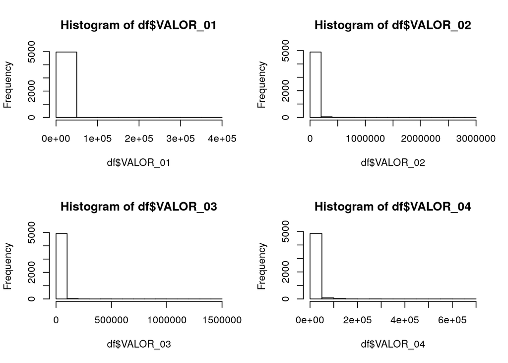

```r
# Variável para armazenar o parâmetro mfrow atual:
numGraf <- par()$mfrow

# 4 gráficos de uma vez
par(mfrow = c(2,2))

# Histograma das variáveis VALOR
hist(df$VALOR_01)
hist(df$VALOR_02)
hist(df$VALOR_03)
hist(df$VALOR_04)
```

```r
# Retorna padrão gráfico
par(mfrow = numGraf)
```

Os histogramas mostraram uma compressão grande no início da escala, não servindo nem para ter uma idéia da distribuição dessas variáveis. Provavelmente os outliers extremos são a causa disso. para ter uma idéia da distribuição, já que os histogramas foram inúteis nesse caso, podemos verificar os quantis:

```r
# Obtendo os quantis detalhados
quantile(df$VALOR_01, seq(0, 1, 0.05))
```

```
##          0%          5%         10%         15%         20%         25%
##      0.0000    265.3634    342.8571    428.5714    571.4286    628.5714
##         30%         35%         40%         45%         50%         55%
##    771.3566    857.1429   1000.0000   1142.8571   1371.4286   1428.5714
##         60%         65%         70%         75%         80%         85%
##   1714.2857   1942.8571   2257.1429   2571.4286   2857.1429   3428.5714
##         90%         95%        100%
##   4285.7143   5714.2857 400000.0000
```

```r
quantile(df$VALOR_02, seq(0, 1, 0.05))
```

```
##           0%           5%          10%          15%          20%
##       0.0000       0.0000       0.0000       0.0000       0.0000
##          25%          30%          35%          40%          45%
##       0.0000       0.0000       0.0000       0.0000       0.0000
##          50%          55%          60%          65%          70%
##       0.0000       0.0000       0.0000     342.8571    2285.7143
##          75%          80%          85%          90%          95%
##    6005.7714   12857.1429   22939.1681   41126.9206   88131.2110
##         100%
## 2857142.8571
```

```r
quantile(df$VALOR_03, seq(0, 1, 0.05))
```

```
##           0%           5%          10%          15%          20%
##       0.0000       0.0000       0.0000       0.0000       0.0000
##          25%          30%          35%          40%          45%
##       0.0000       0.0000       0.0000       0.0000       0.0000
##          50%          55%          60%          65%          70%
##       0.0000       0.0000       0.0000       0.0000       0.0000
##          75%          80%          85%          90%          95%
##       0.0000       0.0000     285.7143    2857.1429   12431.8700
##         100%
## 1428571.4286
```

```r
quantile(df$VALOR_04, seq(0, 1, 0.05))
```

```
##           0%           5%          10%          15%          20%
## 0.000000e+00 0.000000e+00 0.000000e+00 0.000000e+00 0.000000e+00
##          25%          30%          35%          40%          45%
## 0.000000e+00 0.000000e+00 0.000000e+00 0.000000e+00 0.000000e+00
##          50%          55%          60%          65%          70%
## 0.000000e+00 0.000000e+00 2.572571e+00 1.004410e+02 5.142857e+02
##          75%          80%          85%          90%          95%
## 1.428571e+03 2.857143e+03 5.714286e+03 1.142857e+04 2.514286e+04
##         100%
## 6.857143e+05
```

```r
# Contando os possíveis outliers extremos (quantidade maior que P95 e P97):
v1 <- c(sum(df$VALOR_01 > quantile(df$VALOR_01, 0.95)), sum(df$VALOR_01 > quantile(df$VALOR_01, 0.97)))
v2 <- c(sum(df$VALOR_02 > quantile(df$VALOR_01, 0.95)), sum(df$VALOR_02 > quantile(df$VALOR_02, 0.97)))
v3 <- c(sum(df$VALOR_03 > quantile(df$VALOR_01, 0.95)), sum(df$VALOR_03 > quantile(df$VALOR_03, 0.97)))
v4 <- c(sum(df$VALOR_04 > quantile(df$VALOR_01, 0.95)), sum(df$VALOR_04 > quantile(df$VALOR_04, 0.97)))
# Gera matriz:
posOut <- matrix(c(v1, v2, v3, v4), nrow = 4, ncol = 2, byrow = TRUE)
# Nomes das linhas e colunas da matriz
rownames(posOut) <- c("VALOR_O1", "VALOR_O2", "VALOR_O3", "VALOR_O4")
colnames(posOut) <- c(">P95", ">P97")
posOut
```

```
##          >P95 >P97
## VALOR_O1  186  150
## VALOR_O2 1250  137
## VALOR_O3  361  150
## VALOR_O4  698  150
```

Como podemos ver algumas poucas observações podem ser outliers extremos e estão causando uma influência enorme da distribuição das variáveis VALOR. Entretanto, devido ao limite de tempo deste estudo de caso, não faremos um estudo mais detalhado desses outliers e os materemos na análise, assumindo os riscos de que o modelo de clusterização possa ser influenciado de algum modo por esses outliers.

Além dos outliers as variáveis numéricas estão em escalas muito diferentes e precisam ser padronizadas. Como agora começaremos, de fato, a alterar o dataset, também ajustaremos o seed para a reprodutibilidade da análise:

```r
# Ajusta seed para reprodutibilidade
set.seed(999)

# Padroniza variáveis numéricas, criando uma outra variável com a letra "p" no final
df$GEO_REFERENCIAp <- scale(df$GEO_REFERENCIA)
df$VALOR_01p <- scale(df$VALOR_01)
df$VALOR_02p <- scale(df$VALOR_02)
df$VALOR_03p <- scale(df$VALOR_03)
df$VALOR_04p <- scale(df$VALOR_04)
```

Outras análises introdutórias ou técnicas de redução da dimensionalidade e/ou de seleção das variáveis (*feature selection*) poderiam ser realizadas, mas o dataset já está em condições de uma primeira clusterização exploratória.

## Clusterização

A clusterização não é um método ou algoritmo em si mesma: ela é o processo de separar grupos similares de um conjunto de dados, e pode ser realizada por diferentes métodos e algoritmos:

- Métodos baseados em **modelos probabilísticos** (por exemplo: *mixture models — Gaussian, Bernoulli, Hidden Markov —* e algoritmos *Expectation Maximization — EM*)
- Métodos **hierárquicos** (por exemplo: *Agglomerative Clustering*, *Divisive Clustering*)
- Métodos baseados em **particionamento** (por exemplo: *K-Means*, *K-Medoids*, *Fuzzy K-Means*)
- Métodos baseados em **densidade** (por exemplo: *DBSCAN*, *DENCLUE*)
- Métodos baseadas em **grid** (por exemplo: *GRIDCLUS*, *BANG*, *AMR*)
- Métodos baseados em **fatorizações de matrizes**_ (por exemplo: *NMF: nonnegative matrix factorizations*)
- Métodos **espectrais** (por exemplo: *unnormalized spectral clustering*)

A quantidade de métodos e algoritmos para clusterização é muito maior do que a apresentada na lista acima e, além disso, ainda existem variações dependendo se os dados são de alta dimensionalidade, se são uma *stream* de big data, se são categóricos, se são texto, se são multimídia (áudio, imagens, vídeos), séries temporais, se biológicos, se são dados em rede e muitos outros. Também podem ser utilizadas técnicas de *ensembles*, que são o agrupamento de dois ou mais métodos de clusterização para melhorar os resultados.

O assunto é extenso e para uma análise profunda e detalhada recomendo o livro [*Data Clustering: Algorithms and Applications*](https://www.amazon.com/gp/product/1466558210/ref=as_li_tl?ie=UTF8&camp=1789&creative=9325&creativeASIN=1466558210&linkCode=as2&tag=abrantesasf02-20&linkId=e4ab39d3228046864664b0898d8c164c), editado por *Charu C. Aggarwal* e *Chandan K. Reddy*.

Em nossa clusterização exploratória, utilizaremos um método de particionamento baseado no algoritmo *K-Means* que, apesar de ser um dos métodos de clusterização mais simples, é bem eficiente e pode servir como base e referẽncia para clusterizações com métodos mais complexos.

Vamos fazer mais algumas operações de ajuste no dataset para que o K-Means possa ser executado:

```r
# Criando outro dataset para análise
df2 <- df[, c("GEO_REFERENCIAp",
              "DATA_NASCIMENTO",
              "PROFISSAO",
              "GENERO",
              "ESTADO_CIVIL",
              "VALOR_01p",
              "VALOR_02p",
              "VALOR_03p",
              "VALOR_04p",
              "PERFIL"
              )]

# Transformando os fatores em números
df2$PERFIL <- scale(as.numeric(df2$PERFIL))
df2$PROFISSAO <- scale(as.numeric(df2$PROFISSAO))
df2$GENERO <- scale(as.numeric(df2$GENERO))
df2$ESTADO_CIVIL <- scale(as.numeric(df2$ESTADO_CIVIL))

# Função para o cálculo da idade:
age <- function(from, to) {
    from_lt = as.POSIXlt(from)
    to_lt = as.POSIXlt(to)

    age = to_lt$year - from_lt$year

    ifelse(to_lt$mon < from_lt$mon |
               (to_lt$mon == from_lt$mon & to_lt$mday < from_lt$mday),
           age - 1, age)
}

# Altera a data de nascimento para ano
df2$DATA_NASCIMENTO <- age(df2$DATA_NASCIMENTO, Sys.time())
df2$DATA_NASCIMENTO <- scale(df2$DATA_NASCIMENTO)
```

Como clusterização exploratória, faremos uma análise de componentes principais e utilizaremos os 2 primeiros componentes como as variáveis para o K-Means (isso facilita a visualização dessa clusterização inicial).

Usaremos como número inicial de clusters, k = 6:

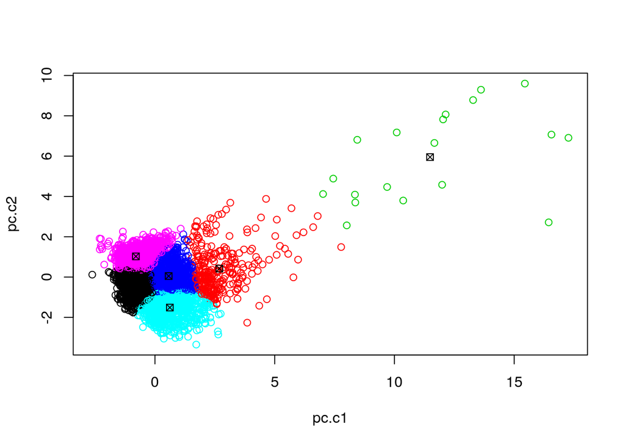

```r
# Faz a PCA:
pca <- princomp(df2, cor = T)

# Obtém componentes
pc.c <- pca$scores
pc.c1 <- -1*pc.c[,1]
pc.c2 <- -1*pc.c[,2]

# Dados para o K-means
df3 <- cbind(pc.c1, pc.c2)

# Número de clusters
k = 6

# Executa K-means
cl <- kmeans(df3, k)

# Plota resultados
plot(pc.c1, pc.c2,col=cl$cluster)
points(cl$centers, pch=7)
```

Essa clusterização exploratória, com 6 clusters, mostrou que 5 deles estão praticamente juntos e 1 cluster está bem separado dos demais. É de se investigar se o agrupamento dos 5 clusters não está sendo causado por algum outro fator, como os outliers.

## Abordagens posteriores

Fizemos uma clusterização exploratória onde encontramos como resultado um “conglomerado” de clusters bem próximos, separados de um único cluster. Esse resultado inicial é importante para levantar mais questionamentos, mas precisa ser muito apurado ainda.

Primeiro teremos que avaliar se os outliers estão causando alguma influência na clusterização e, se essa influência for capaz de mudar consideravelmente o resultado, teremos que decidir entre manter ou remover ou outliers.

Depois temos que decidir qual o número ideal de cluster. Não existe nenhum regra padrão para isso, embora técnicas como o “elbow plot” possam dar alguns insights. Outras técnicas como por exemplo a *Bayesian Information Criterion (BIC)* ou a *Akaike Information Criterion (AIC)* também podem ser utilizadas para definir o número de clusters.

Técnicas mais avançadas de *ensembles* também pode ser utilizadas para tentar melhorar a clusterização.